# ABM Spaces analysis rendered using RMarkdown

Marcus Low

8 December 2020

# What we found

The below is based on 10000 runs of each scenario.

|  | TaT | Infections_no_cti | Infections_cti_test | Infections_cti_no_test | Dead_no_cti | Dead_cti_test | Dead_cti_no_test | R0_no_cti | R0_cti_test | R0_cti_no_test | Tests_no_cti | Tests_cti_test | Tests_cti_no_test |
| --- | --- | --- | --- | --- | --- | --- | --- | --- | --- | --- | --- | --- | --- |
| 1 | 2 | 5850.5044 | 4438.8414 | 4827.8592 | 36.4365 | 31.6046 | 33.3283 | 1.683845372 | 1.637024896 | 1.655360895 | 1443.1711 | 11870.0579 | 1188.8111 |
| 2 | 3 | 5849.9542 | 4613.6148 | 4922.7153 | 36.5711 | 33.1316 | 34.0006 | 1.683858159 | 1.655280587 | 1.663579664 | 1439.5156 | 11957.2548 | 1209.5923 |
| 3 | 4 | 5850.0292 | 4776.1643 | 5019.9647 | 36.7414 | 33.9122 | 34.5895 | 1.683685981 | 1.666094145 | 1.669939102 | 1436.9391 | 12235.4412 | 1229.409 |
| 4 | 5 | 5850.0222 | 4934.5012 | 5123.3265 | 36.5678 | 34.7417 | 34.8743 | 1.683485239 | 1.673115818 | 1.674299318 | 1432.7141 | 12504.0646 | 1252.0575 |
| 5 | 6 | 5850.087 | 5082.3963 | 5229.6983 | 36.6597 | 35.3573 | 35.3487 | 1.683818069 | 1.677272671 | 1.67777496 | 1431.8906 | 12387.966 | 1276.3375 |
| 6 | 7 | 5850.5419 | 5212.3968 | 5328.6771 | 36.5553 | 35.6271 | 35.7943 | 1.683980378 | 1.680109032 | 1.680027077 | 1429.9403 | 12123.7036 | 1299.7033 |
| 7 | 8 | 5849.4018 | 5324.8853 | 5416.6643 | 36.4728 | 35.9255 | 36.1944 | 1.683661252 | 1.681371449 | 1.681602167 | 1428.8031 | 11844.8699 | 1320.3385 |
| 8 | 9 | 5848.7657 | 5421.9235 | 5496.053 | 36.5785 | 36.0063 | 36.2321 | 1.683586043 | 1.682081807 | 1.682432806 | 1428.2098 | 11512.2229 | 1339.3296 |
| 9 | 10 | 5849.2307 | 5510.8953 | 5569.9108 | 36.5037 | 36.301 | 36.112 | 1.683169472 | 1.68287147 | 1.682951723 | 1427.5776 | 11006.8105 | 1357.8978 |
| 10 | 11 | 5847.9828 | 5594.6913 | 5638.9522 | 36.5188 | 36.4192 | 36.4329 | 1.683146247 | 1.683520827 | 1.683000125 | 1426.3452 | 10097.205 | 1374.1143 |

# Some important 95% uncertainty ranges

Infections and TAT = 2:

No CTI 5692 6013.025

CTI with testing 4316 4566.025

CTI without testing 4694 4963

Deaths and TAT = 2:

No CTI 15 59

CTI with testing 11 54

CTI without testing 12 56

Number of tests and TAT = 2:

No CTI 1369 1519

CTI without testing 1126 1252

Infections and TAT = 8:

No CTI 5689 6011

CTI with testing 5184 5468

CTI without testing 5271 5560.05

Deaths and TAT = 8:

No CTI 15 60

CTI with testing 14 59

CTI without testing 15 59

# Plots

Infections This plot shows how total infections rise with longer TaTs. The three lines are for no CTI, CTI with testing of contacts, and CTI without testing of contacts. (The code for this graph can be improved in the file ultra.rmd.)

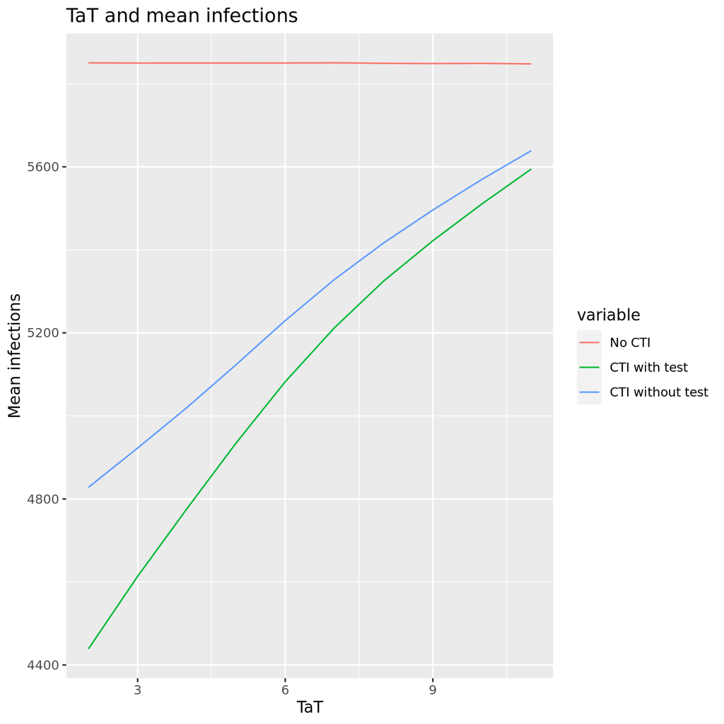

Deaths This plot shows how total mean deaths rise with longer TaTs. The three lines are for no CTI, CTI with testing of contacts, and CTI without testing of contacts. (The code for this graph can be improved in the file ultra.rmd.)

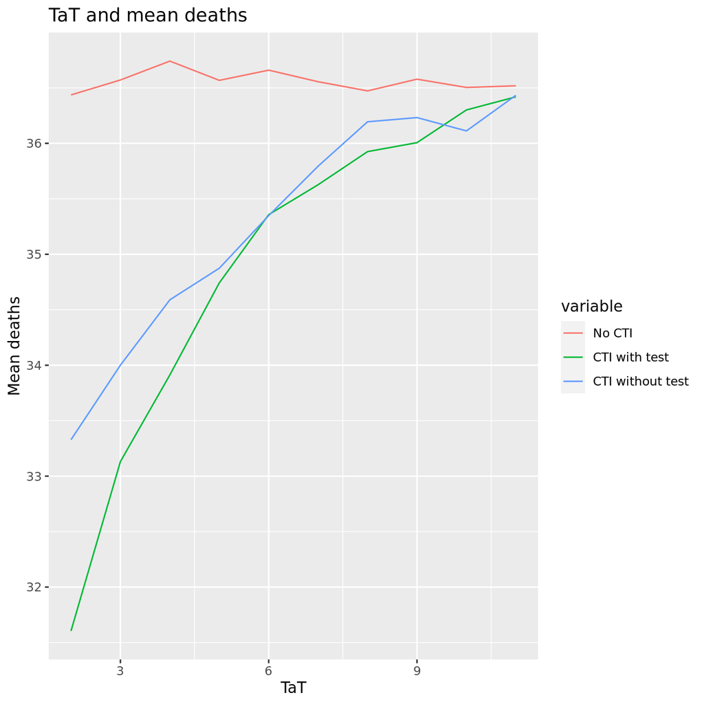

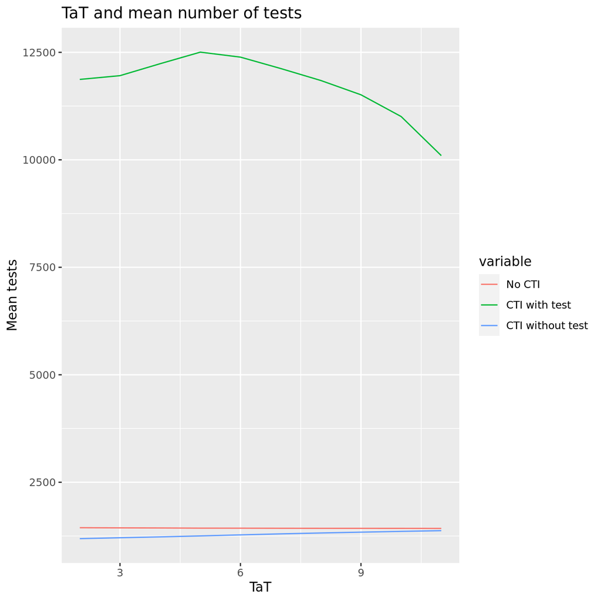

# Differences between TaT values

[output not shown]